# SHIPS Tropical Cyclone Data Set

Sarah M. Reehl

January 27, 2016

## Background

The [Tropical Cyclones Developmental Dataset](http://rammb.cira.colostate.edu/research/tropical_cyclones/ships/developmental_data.asp) was used to develop the [Statistical Hurricane Intensity Prediction Scheme](http://rammb.cira.colostate.edu/research/tropical_cyclones/ships/) (SHIPS) for predicting changes in tropical cyclone (TC) intensities (DeMaria and Kaplan (1994)). The National Hurricane Center (NHC) uses SHIPS, along with other models, to generate predictions and guide official track and intensity forecasts (“NHC Track and Intensity Models” 2009). Traditionally, SHIPS forecasts have outperformed climatology and persistence forecasts since circa 1997. However, SHIPS has not performed well in Rapid Intensification (RI) events, defined as a rapid increase in maximum windspeed over 24 hours exceeding 30, 35, or 40 knots as described in Kaplan and DeMaria (2003).

## Data Description

Focusing on TCs from the Atlantic Basin only, the raw data arrives in a file called *lsdiaga_1982_2014_rean_sat_nbc_ts.dat* which is described as Atlantic data with SHIPS predictors from either re-analysis or operational analysis with satellite variables when available. The file is one concatenated list of record sets for each storm case. Here, a case includes a current time observation (hour 0) in addition to 120 hours of forecast information (hours 6 to 120) and, in some cases, 12 hours of past information (hours -12 to -6). The case time points occur in 6 hour intervals. Each of the different cases begin with a line descriptor called **HEAD** and end with an end-line called **LAST**. Not all predictors are available for all years. To make the *.dat* file in a readable format, we treated each record as a fixed width format (fwf) table, skipping the header rows, with 24 columns of width 5. Once the fwf table was parsed, the table was transposed to place the attributes as columns and time points as rows. The missing value string `9999` is replaced with `NA`s and the parsed, transposed, and cleaned record is written to a `.csv` file for the sake a creating a bank of easily accessible records. As there are multiple records for one TC, the `.csv` file names are written as `uniquestormID.recordnumber.csv`.

The next step in preprocessing the data was to concatenate the **hour 0** observations for each case for each storm. Before adding the observation to a master data frame, we crosschecked observations of corresponding time points. If the cases are recorded correctly, for a given storm hours 0 to 114 of the current case should be equivalent with hours 6 to 120 of the previous case for time dependent predictors. To keep track of case discrepancies, we appended a column call **Match** to the master data frame. Below is a detailed description of each of the raw attributes of the master data frame, mostly adapted from the predictor [description file](http://rammb.cira.colostate.edu/research/tropical_cyclones/ships/developmental_data.asp).

| Attribute Name | Description |
| --- | --- |
| **ID** | chr. Storm identifier. The first two characters “AL” represent the Atlantic basin, the second two characters represent the sequence number of a TC in a certain year, and the remaining four characters … |
| **DATE** | POSIXct. Date of the storm in the format *yymmdd* |
| **TIMESTAMP** | POSIXct. Date of the storm in the format *yymmdd HH* |
| **RECORDNM** | num. The time intervals are currently in fixing. This is the record number from the original .dat file |
| **VMAX** | int. Maximum wind surface (kts) |
| **MSLP** | int. Minimum sea level pressure (hPa) |
| **TYPE** | factor. Storm type type (0=wave, remnant low, dissipating low, 1 = tropical, 2 = subtropical, NA = extra-tropical). |
| **HIST20**-**HIST120** | int. Number of 6 hour periods that the storm max wind has been above 20, 25, … 120 kts. |
| **DELV** | int. Intensity change relative to the storm start (kts) |
| **INCV** | int. Intensity change relative to the previous 6 hour interval. Set to NA for land mass crossings |
| **LAT** | int. The latitude in 10*degrees North of the approximate storm center |
| **LON** | int. The longitude in 10*degrees West of the approximate storm center |
| **CSST** | int. Climatological sea surface temperature (deg C*10) |
| **CD20** | int. Climatoligical depth (m) of 20 degree isotherm from 2005-2010 NCODA analyses |
| **CD26** | int. Climatoligical depth (m) of 26 degree isotherm from 2005-2010 NCODA analyses |
| **COHC** | int. Climatoligical ocean heat content (kJ/cm^2) 2005-2010 NCODA analyses |
| **DTL** | int. Distance to nearest major land mass (km) |
| **RSST** | int. Reynolds sea surface temperature ( deg C*10) |
| **PCHN** | int. Estimated ocean heat content(kJ/cm^2) from **COHC** and current sea surface temperature anomaly. Designed to fill in missing **RHCN** |
| **U200** | int. 200 hPa zonal wind speed (10*kts) for r = 200-800 km on average |
| **U20C** | int. 200 hPa zonal wind speed (10*kts) for r = 0-500 km on average |
| **V20C** | int. Vertical component of 200 hPa zonal wind speed(10*kts) for r = 200-800 km on average |
| **E000** | int. 1000 hPa equivalent potential temperature, $\theta_e$ for r = 200-800 km on average (K) |
| **EPOS** | int. Average $\theta_e$ difference between a parcel lifted from the surface and its environment for r = 200-800 km on average (K) |
| **ENEG** | int. Negative average $\theta_e$ difference between a parcel lifted from the surface and its environment for r = 200-800 km on average, sign not included (K) |
| **EPSS** | int. Negative average $\theta_e$ difference between a parcel lifted from the surface and its environment for r = 200-800 km on average, sign not included with $\theta_e$ compared with the saturated $\… |
| **ENSS** | int. Negative average $\theta_e$ difference between a parcel lifted from the surface and its environment for r = 200-800 km on average, sign not included with $\theta_e$ compared with the saturated $\… |
| **RHLO** | int. 850-700 hPa relative humidity(%) for 200-800 km |
| **RHMD** | int. 700-500 hPa relative humidity(%) for 200-800 km |
| **RHHI** | int. 500-300 relative humidity(%) for 200-800 km |

[output cut: 64 more lines]

## Exploratory Analysis

Without any further cleaning, the data is `10705` rows of realtime instances and `135` columns of attributes to each instance. There are `460` unique TCs ranging from `1982-06-02` to `2014-10-28`. The storm paths are again limited to the Atlantic Basin as seen below.

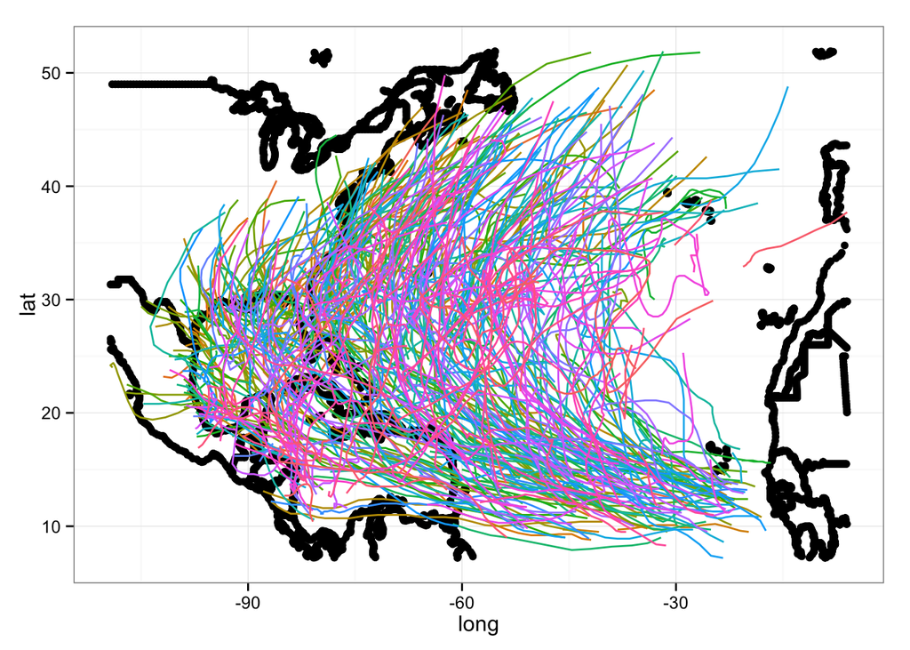

## Detailed Variable Exploration

## Checks and Inconsistencies

In the cross check for time point inconsistencies, there are a total of `38` inconsistencies. As documented in Jankulak (2012), 18 of these inconsistencies belong to the **REFC** attribute. Another 10 of these inconsistencies are due to the **TYPE** attribute. The remaining 10 inconsistencies belong to 9 different storms, where the storm is missing at least one day of data. For example, Hurricane Nadine, the longest storm in this set of records, has a missing cases between 120921 and 120923. We can see the missing data in the lat/long path below

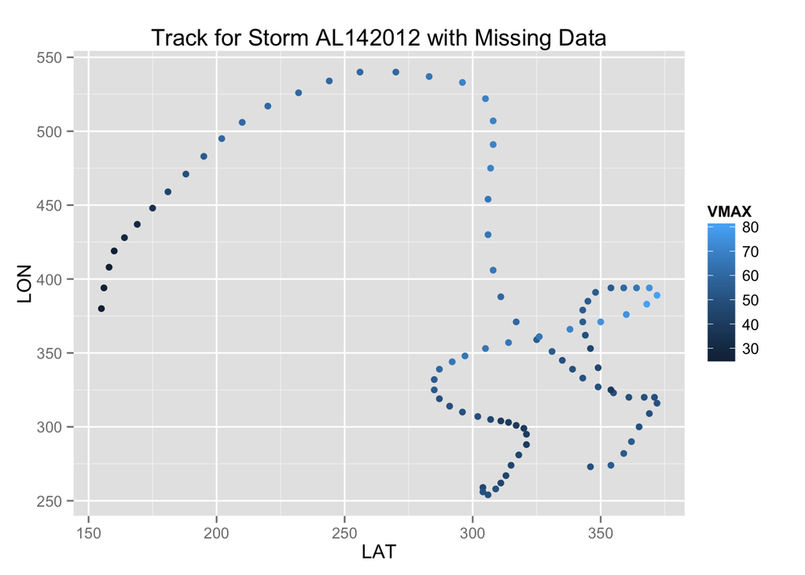

Next, a check to see that the storm history variables beginning with **HIST** are in fact a cumulative history. For the first TC, the **HIST** vars look like:

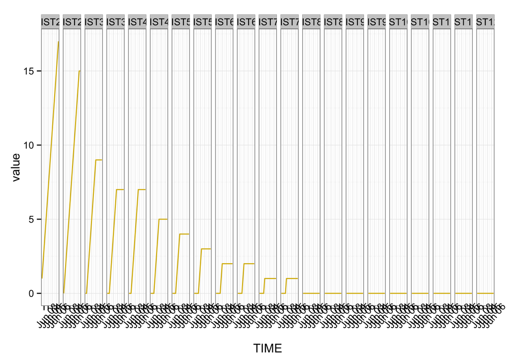

A little messier, all the storms look like:

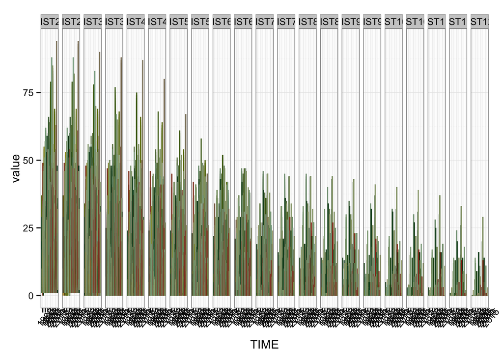

Checking numerically by row that the history variables are different by either 1 or 0 from the previous variable observation by storm, we find a total of 16 storms with history issues, including the 9 storms with time point inconsistencies. These storm IDs,

```
## [1] "AL042013" "AL052011" "AL072012" "AL091997" "AL092014" "AL132005"
## [7] "AL282005"
```

show history inconsistencies, which under further investigation, is a result of date inconsistencies. As it would happen, this data set only includes cases that qualify as tropical or sub-tropical storms. If the storm weakens, it is no longer classified into either of these two categories and the data is no longer available. If the storm picks up speed, the tracking resumes explaining what happened to NADINE and the history inconsistent storms. A small note, there are also inconsistencies between storms in the case-dependent **TYPE** and **REFC** attributes. Without these variables included in the checks and accounting for missing dates, all inconcsistencies are resolved.

### VMAX and TIME

The storm instances have a binary label, 1 indicating RI and 0 indicating nonRI (for any increase in windspeed greater than 30 kts within 24 hrs), in addition to a VMAX_Diff column that measures the future 24 hour change in intensity relative to the current time point. An `NA` in the **RI** and **VMAXDiff** column signify that the data are not available for the timepoints needed to calculate these attributes (storms like NADINE). The distribution of maximum intensities per time interval for the nonRI and RI storms are shown below. Keep in mind that NAs are likely equivalent to nonRI events as the storm has weakened.

### VMAX

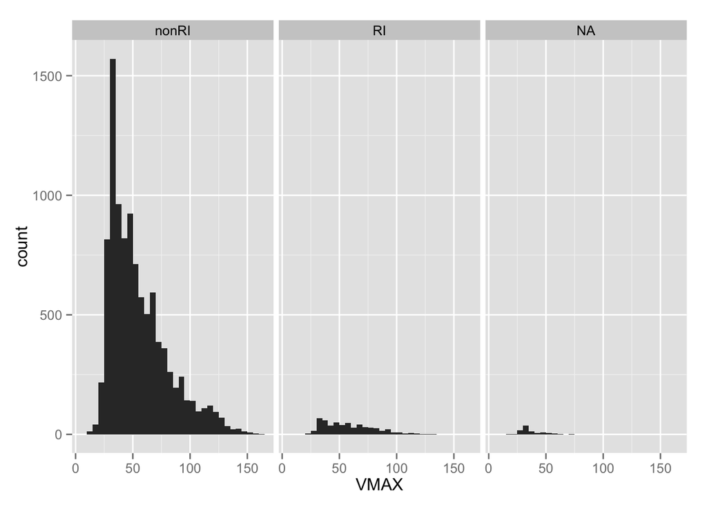

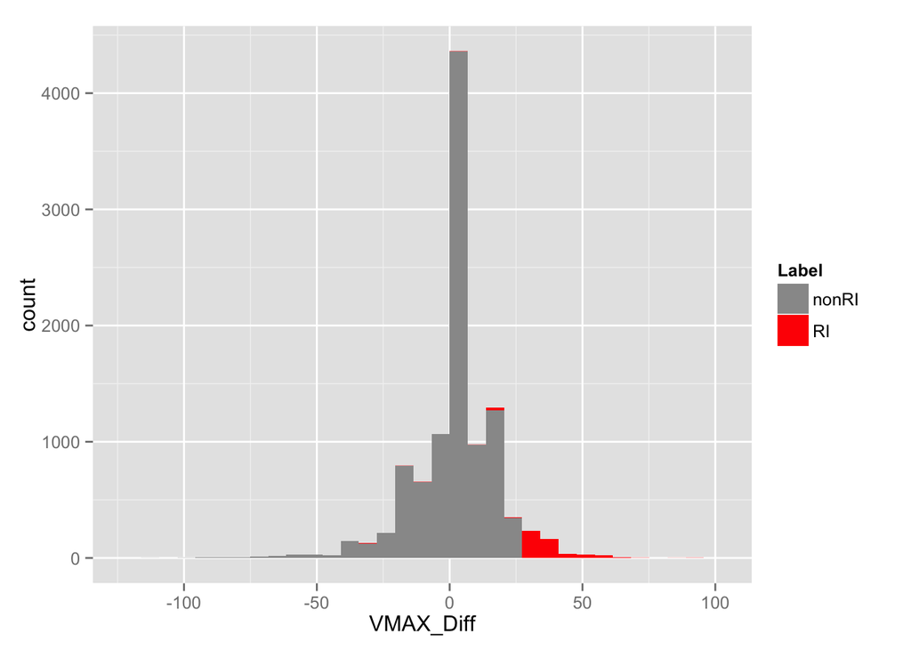

### Time Component

The longest storm in the data is `AL142012` lasting a total of `558` hours. The shortest storm is `AL052010` lasting a total of `6` hours. The distribution of storm duration for all storms, colored by the number of RI events in each storm, looks like:

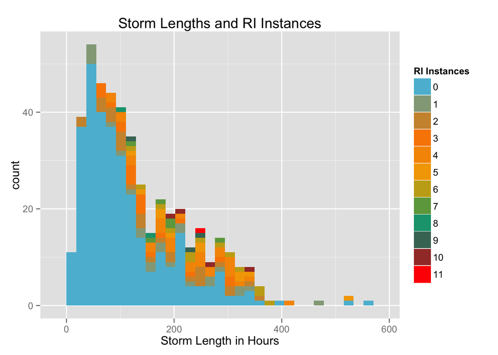

In terms of the time series view, a snapshot look at VMAX vs TIME:

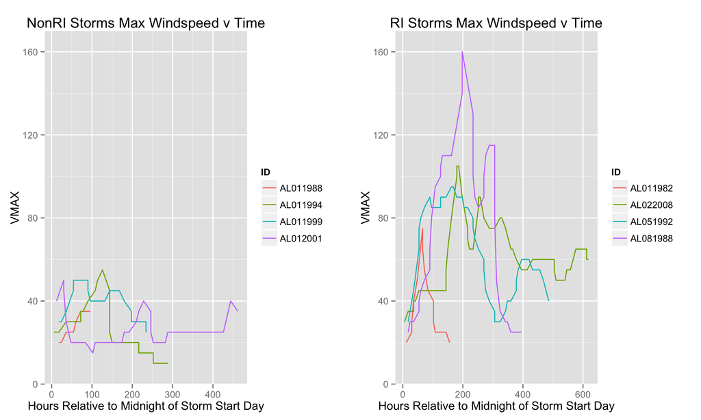

Similarly, the 24 change in maximum windspeed varies widely for the storms that contain RI events.

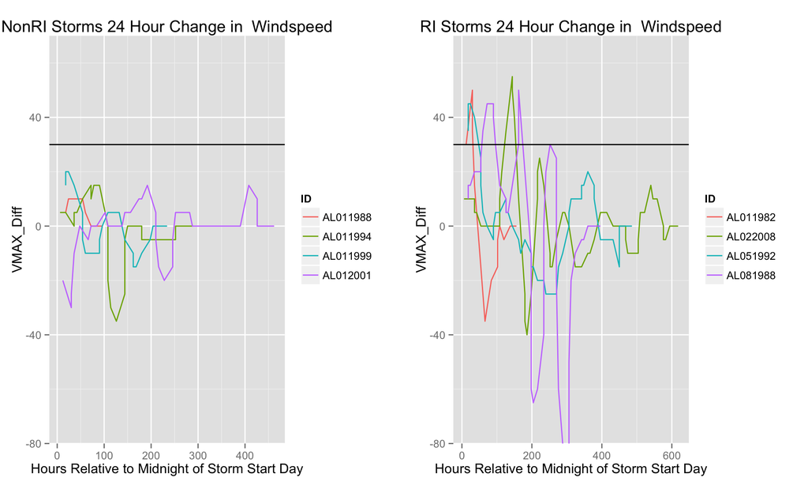

References

DeMaria, Mark, and John Kaplan. 1994. “A Statistical Intensity Prediction Scheme (SHIPS) for the Atlantic Basin.” *Weather and Forescating* 9 (June): 209–20.

Jankulak, Michael L. 2012. “Prediction of Rapid Intensity Changes in Tropical Cyclones Using Associative Classification.” PhD thesis, University of Miami.

Kaplan, John, and Mark DeMaria. 2003. “Large-Scale Characteristics of Rapidly Intensifying Tropical Cyclones in the North Atlantic Basin.” *Weather and Forecasting* 18 (6): 1093–1108.

“NHC Track and Intensity Models.” 2009.